# 第 7 章，作業 1 - A/B 測試概念與個案實作練習

Jung-Cheng Huang

5/30/2021

作業說明 在這個章節的作業中，我們同樣利用「使用者購買行為」的資料集分析實驗設計的結果，了解影響消費者購買金額的重要變因，並探究哪個因素最能夠影響實驗結果。

設置工作路徑，並確定兩個資料集合都放置在你的工作路徑：

```r
# Question: file:///Users/dodsonhuang/Desktop/Schedule_Summer2021/Winter2020/R%E8%AA%9E%E8%A8%80%E5%92%8C%E5%95%86%E6%A5%AD%E5%88%86%E6%9E%90/Chapter6/ab_test.html
# Required Library
library("tidyverse")
# Please set your own working directory
setwd("/Users/dodsonhuang/Desktop/Schedule_Summer2021/Winter2020/R語言和商業分析/Chapter6")

# Read Dataset
test.table <- read_csv("test_table.csv", locale= locale(encoding='UTF-8'))
user.table <- read_csv("user_table.csv", locale= locale(encoding='UTF-8'))
#為了避免程式中的隨機效果造成答案不一致，請將隨機種子設置為500：
set.seed(500)
```

確定了實驗個體後，我們就可以來合併實驗表格與使用者資料，邏輯應該是：test_table要全部資料都有，user_table則不需要，因此採用 left_join 的方式。

```r
test.data <- left_join(test.table,
                       user.table,
                       by = "user_id")

head(test.data)
```

```
## # A tibble: 6 x 9
##   user_id date     device      test purchase_amount gender service   age country
##     <dbl> <chr>    <chr>      <dbl>           <dbl> <chr>  <chr>   <dbl> <chr>
## 1    1983 2017/1/1 pc_web         0            33.7 male   golden     37 US
## 2    4704 2017/1/1 android_a…     1            30.2 male   golden     33 UK
## 3   14995 2017/1/1 ios_app        0            37.2 male   golden     31 US
## 4   15089 2017/1/1 pc_web         0            49.8 male   golden     38 US
## 5   17522 2017/1/1 pc_web         0            19.7 male   normal     35 UK
## 6     186 2017/1/1 pc_web         1            33.6 female golden     50 BR
```

在資料裡面最大的問題就是：date 應該是日期變數，以及眾多資料其實是因子變數。因此，我們需要做變數類別的轉換。

```r
test.data$date <- as.Date(test.data$date, format = "%Y/%m/%d")

for(i in c(3,4,6,7,9)){
  test.data[,i] <- as.factor(test.data[[i]])
}

head(test.data)
```

```
## # A tibble: 6 x 9
##   user_id date       device   test  purchase_amount gender service   age country
##     <dbl> <date>     <fct>    <fct>           <dbl> <fct>  <fct>   <dbl> <fct>
## 1    1983 2017-01-01 pc_web   0                33.7 male   golden     37 US
## 2    4704 2017-01-01 android… 1                30.2 male   golden     33 UK
## 3   14995 2017-01-01 ios_app  0                37.2 male   golden     31 US
## 4   15089 2017-01-01 pc_web   0                49.8 male   golden     38 US
## 5   17522 2017-01-01 pc_web   0                19.7 male   normal     35 UK
## 6     186 2017-01-01 pc_web   1                33.6 female golden     50 BR
```

題目一

篩選出屬於日本市場的使用者，針對購買金額進行獨立樣本 t 檢定。請問：實驗組的購買金額有沒有顯著高於對照組的購買金額？

反之，針對購買金額進行獨立樣本 t 檢定，對照組金額有沒有顯著高於實驗組金額？

請利用 ggplot2 繪製實驗組與對照組購買金額機率密度圖 (density plot)。

日本與實驗組間的交互影響

```r
test.data %>%
  group_by(country, test) %>%
  filter(country=='JP') %>%
  summarise(mean_purchase_amount = mean(purchase_amount))
```

```
## # A tibble: 2 x 3
## # Groups:   country [1]
##   country test  mean_purchase_amount
##   <fct>   <fct>                <dbl>
## 1 JP      0                     43.6
## 2 JP      1                     34.5
```

篩選出屬於日本市場的使用者，針對購買金額進行獨立樣本 t 檢定。請問：實驗組的購買金額有沒有顯著高於對照組的購買金額？

```r
#test.data <- test.data %>% filter(country == "JP")
JP.data <- filter(test.data,country=="JP")

t.test(JP.data[JP.data$test == 1, ]$purchase_amount,
       JP.data[JP.data$test == 0, ]$purchase_amount,
       alternative = "greater")
```

```
##
##  Welch Two Sample t-test
##
## data:  JP.data[JP.data$test == 1, ]$purchase_amount and JP.data[JP.data$test == 0, ]$purchase_amount
## t = -63.113, df = 9953.1, p-value = 1
## alternative hypothesis: true difference in means is greater than 0
## 95 percent confidence interval:
##  -9.297706       Inf
## sample estimates:
## mean of x mean of y
##  34.50391  43.56543
```

```r
# No, it's lower than control group.
```

反之，針對購買金額進行獨立樣本 t 檢定，對照組金額有沒有顯著高於實驗組金額？

```r
t.test(JP.data[JP.data$test == 1, ]$purchase_amount,
       JP.data[JP.data$test == 0, ]$purchase_amount,
       alternative = "less")
```

```
##
##  Welch Two Sample t-test
##
## data:  JP.data[JP.data$test == 1, ]$purchase_amount and JP.data[JP.data$test == 0, ]$purchase_amount
## t = -63.113, df = 9953.1, p-value < 2.2e-16
## alternative hypothesis: true difference in means is less than 0
## 95 percent confidence interval:
##       -Inf -8.825337
## sample estimates:
## mean of x mean of y
##  34.50391  43.56543
```

```r
# 有
```

請利用 ggplot2 繪製實驗組與對照組購買金額機率密度圖 (density plot)。

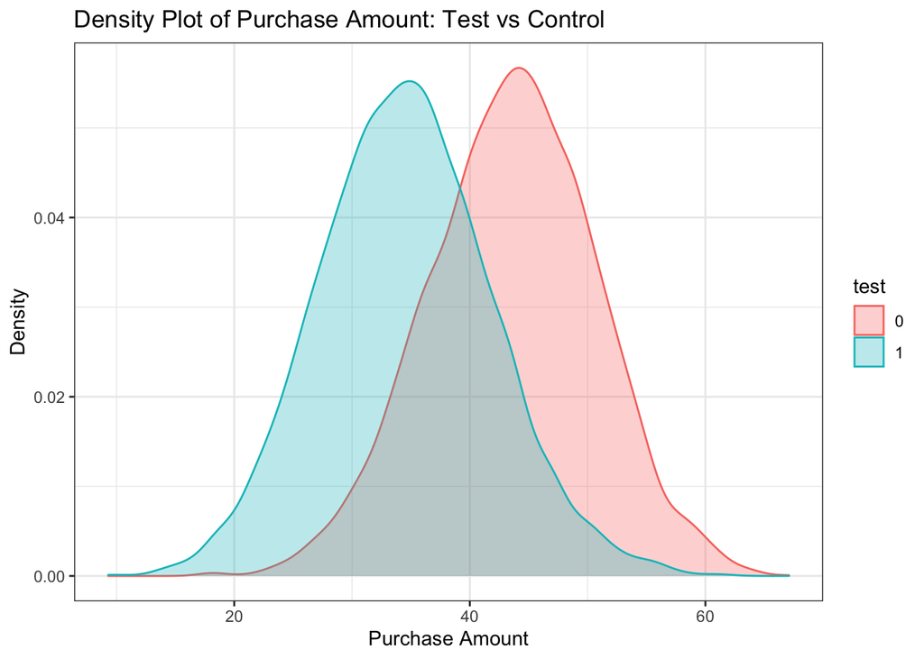

```r
ggplot(JP.data, aes(purchase_amount, fill = test, colour = test)) +
  geom_density(alpha = 0.3) +
  xlab("Purchase Amount") + ylab("Density") +
  ggtitle("Density Plot of Purchase Amount: Test vs Control") +
  theme_bw()
```

題目二

建立購物金額與是否為實驗組、設備、性別與服務的變異數分析(ANOVA)模型。請問，模型中有哪些因子是顯著的？ 請利用 ggplot2 繪製購買金額對應不同服務的盒狀圖 (boxplot)。 請進行 Tukey 事後檢定，了解 test 對於購買金額的影響，並繪製信賴區間圖形。 請進行 Tukey 事後檢定，了解 device 對於購買金額的影響，並繪製信賴區間圖形。

建立購物金額與是否為實驗組、設備、性別與服務的變異數分析(ANOVA)模型。請問，模型中有哪些因子是顯著的？

```r
aov.model <- aov(
  purchase_amount ~ test + device + gender + service,
  JP.data)
summary(aov.model)
```

```
##               Df Sum Sq Mean Sq  F value Pr(>F)
## test           1 204387  204387 5434.724 <2e-16 ***
## device         2  43561   21780  579.146 <2e-16 ***
## gender         1      3       3    0.082  0.774
## service        2  93222   46611 1239.405 <2e-16 ***
## Residuals   9950 374196      38
## ---
## Signif. codes:  0 '***' 0.001 '**' 0.01 '*' 0.05 '.' 0.1 ' ' 1
```

```r
# Ans: test, device, service.
```

請利用 ggplot2 繪製購買金額對應不同服務的盒狀圖 (boxplot)。

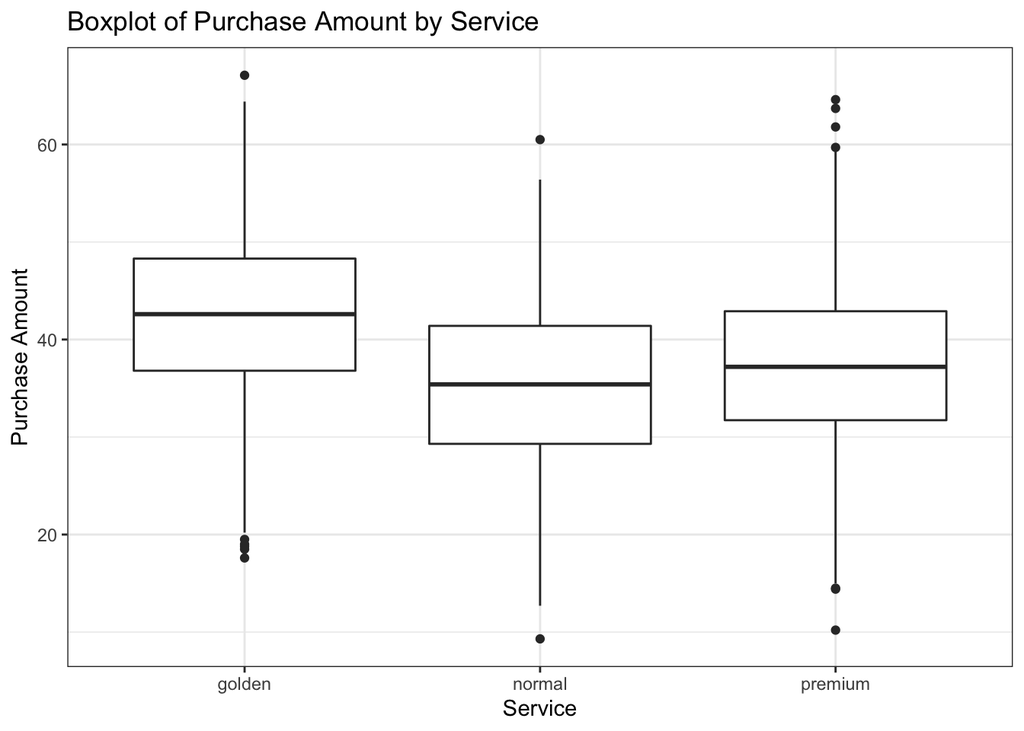

```r
ggplot(JP.data, aes(x = service, y = purchase_amount)) +
  geom_boxplot() +
  xlab("Service") + ylab("Purchase Amount") +
  ggtitle("Boxplot of Purchase Amount by Service") +
  theme_bw()
```

```r
test.data %>%
  group_by(country, service) %>%
  filter(country=='JP') %>%
  summarise(mean_purchase_amount = mean(purchase_amount))
```

```
## # A tibble: 3 x 3
## # Groups:   country [1]
##   country service mean_purchase_amount
##   <fct>   <fct>                  <dbl>
## 1 JP      golden                  42.5
## 2 JP      normal                  35.3
## 3 JP      premium                 37.3
```

請進行 Tukey 事後檢定，了解 test 對於購買金額的影響，並繪製信賴區間圖形。

```r
TukeyHSD(aov.model, "test")
```

```
##   Tukey multiple comparisons of means
##     95% family-wise confidence level
##
## Fit: aov(formula = purchase_amount ~ test + device + gender + service, data = JP.data)
##
## $test
##          diff       lwr       upr p adj
## 1-0 -9.061521 -9.302464 -8.820579     0
```

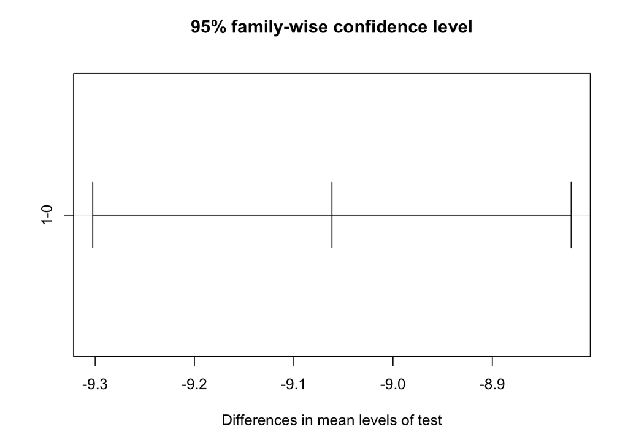

```r
plot(TukeyHSD(aov.model, "test"))
```

請進行 Tukey 事後檢定，了解 device 對於購買金額的影響，並繪製信賴區間圖形。

```r
TukeyHSD(aov.model, "device")
```

```
##   Tukey multiple comparisons of means
##     95% family-wise confidence level
##
## Fit: aov(formula = purchase_amount ~ test + device + gender + service, data = JP.data)
##
## $device
##                          diff       lwr       upr p adj
## ios_app-android_app  5.681998  5.290501  6.073495     0
## pc_web-android_app   3.681216  3.286400  4.076033     0
## pc_web-ios_app      -2.000782 -2.323508 -1.678056     0
```

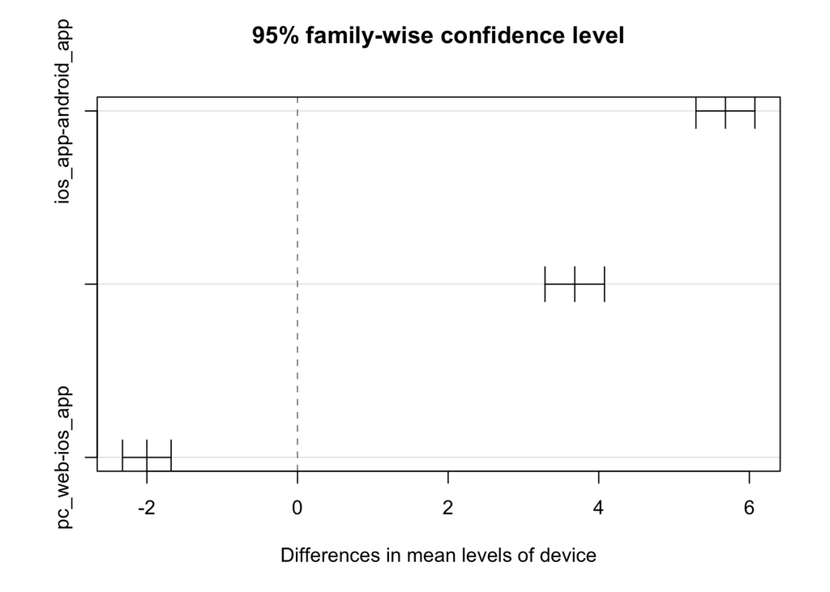

```r
plot(TukeyHSD(aov.model, "device"))
```